# Practical Machine Learning Prediction Assignment

## Background

Using devices such as Jawbone Up, Nike FuelBand, and Fitbit it is now possible to collect a large amount of data about personal activity relatively inexpensively. These type of devices are part of the quantified self movement - a group of enthusiasts who take measurements about themselves regularly to improve their health, to find patterns in their behavior, or because they are tech geeks. One thing that people regularly do is quantify how much of a particular activity they do, but they rarely quantify how well they do it. The goal pf this project will be to use data from accelerometers on the belt, forearm, arm, and dumbell of 6 participants. They were asked to perform barbell lifts correctly and incorrectly in 5 different ways.

The data for this project come from this source: http://groupware.les.inf.puc-rio.br/har.

### Library and Initial Set Up

Load required libraries

```r
#load libraries
library(tree)
library(caret)
library(rpart)
```

```r
library(rpart.plot)
library(rattle)
require(randomForest)
```

Set seed to ensure results are reproducible.

```r
set.seed(12345)
```

## Data

The training data for this project are available here:

https://d396qusza40orc.cloudfront.net/predmachlearn/pml-training.csv

The test data are available here:

https://d396qusza40orc.cloudfront.net/predmachlearn/pml-testing.csv

The data was downloaded in the working directory.

```r
#read train and test data
TrainFile <- "pml-training.csv"
training <- read.csv(TrainFile, na.strings = c("NA","#DIV/0!",""))
TestFile <- "pml-testing.csv"
testing <- read.csv(TestFile, na.strings = c("NA","#DIV/0!",""))
```

### Training Data Partioning and Cleanup

We will partition the training data into a smaller training and testing set (60/40). After which we will proceed with some cleanup.

```r
inTrain <- createDataPartition(y=training$classe, p=0.6, list=FALSE)
myTraining <- training[inTrain, ]
myTesting <- training[-inTrain, ]
dim(myTraining); dim(myTesting)
```

```
## [1] 11776   160
```

```
## [1] 7846  160
```

Our data includes NA variables, variables that might not be relevant or related to the dependent variable, variables that have near zero variance, and variables that are highly correlated. We will remove these before creating our models.

```r
#remove NA variables
myTraining.deNA <- myTraining[ , colSums(is.na(myTraining)) == 0]
myTesting.deNA <- myTesting[ , colSums(is.na(myTesting)) == 0]
dim(myTraining.deNA); dim(myTesting.deNA)
```

```
## [1] 11776    60
```

```
## [1] 7846   60
```

```r
#remove unlelevant variables
remove = c('X','user_name','raw_timestamp_part_1','raw_timestamp_part_2','cvtd_timestamp','new_window','num_window')
myTraining.deRel <- myTraining.deNA[,-which(names(myTraining.deNA) %in% remove)]
myTesting.deRel <- myTesting.deNA[,-which(names(myTesting.deNA) %in% remove)]
dim(myTraining.deRel); dim(myTesting.deRel)
```

```
## [1] 11776    53
```

```
## [1] 7846   53
```

```r
#remove variales with very low variance
zeroVar_train = nearZeroVar(myTraining.deRel[sapply(myTraining.deRel, is.numeric)],saveMetrics = TRUE)
myTraining.nonZeroVar <- myTraining.deRel[,zeroVar_train[,'nzv']==0]
zeroVar_test = nearZeroVar(myTesting.deRel[sapply(myTesting.deRel, is.numeric)],saveMetrics = TRUE)
myTesting.nonZeroVar <- myTesting.deRel[,zeroVar_test[,'nzv']==0]
dim(myTraining.nonZeroVar); dim(myTesting.nonZeroVar)
```

```
## [1] 11776    53
```

```
## [1] 7846   53
```

```r
#remove highly correlated variables
corMat <- cor(na.omit(myTraining.nonZeroVar[sapply(myTraining.nonZeroVar,is.numeric)]))
dim(corMat)
```

```
## [1] 52 52
```

```r
removeCor_idx <- findCorrelation(corMat,cutoff = .90, verbose=TRUE)
```

```
## Compare row 10  and column  1 with corr  0.992
##   Means:  0.271 vs 0.168 so flagging column 10
## Compare row 1  and column  9 with corr  0.923
##   Means:  0.251 vs 0.165 so flagging column 1
## Compare row 9  and column  4 with corr  0.928
##   Means:  0.233 vs 0.162 so flagging column 9
## Compare row 8  and column  2 with corr  0.966
##   Means:  0.244 vs 0.158 so flagging column 8
## Compare row 19  and column  18 with corr  0.918
##   Means:  0.092 vs 0.158 so flagging column 18
## Compare row 46  and column  31 with corr  0.947
##   Means:  0.104 vs 0.161 so flagging column 31
## Compare row 46  and column  33 with corr  0.959
##   Means:  0.085 vs 0.165 so flagging column 33
## All correlations <= 0.9
```

```r
myTraining.deCor <- myTraining.nonZeroVar[,-removeCor_idx]
myTesting.deCor <- myTesting.nonZeroVar[,-removeCor_idx]
dim(myTraining.deCor); dim(myTesting.deCor)
```

```
## [1] 11776    46
```

```
## [1] 7846   46
```

## Analysis

### Regression Tree Analysis

```r
tree.training = tree(classe~.,data=myTraining.deCor)
summary(tree.training)
```

```
##
## Classification tree:
## tree(formula = classe ~ ., data = myTraining.deCor)
## Variables actually used in tree construction:
##  [1] "pitch_forearm"     "magnet_belt_y"     "accel_forearm_z"
##  [4] "magnet_dumbbell_y" "roll_forearm"      "magnet_dumbbell_z"
##  [7] "pitch_belt"        "yaw_belt"          "accel_dumbbell_y"
## [10] "accel_forearm_y"   "accel_forearm_x"   "magnet_arm_x"
## [13] "accel_dumbbell_z"  "gyros_belt_z"
## Number of terminal nodes:  24
## Residual mean deviance:  1.515 = 17810 / 11750
## Misclassification error rate: 0.2787 = 3282 / 11776
```

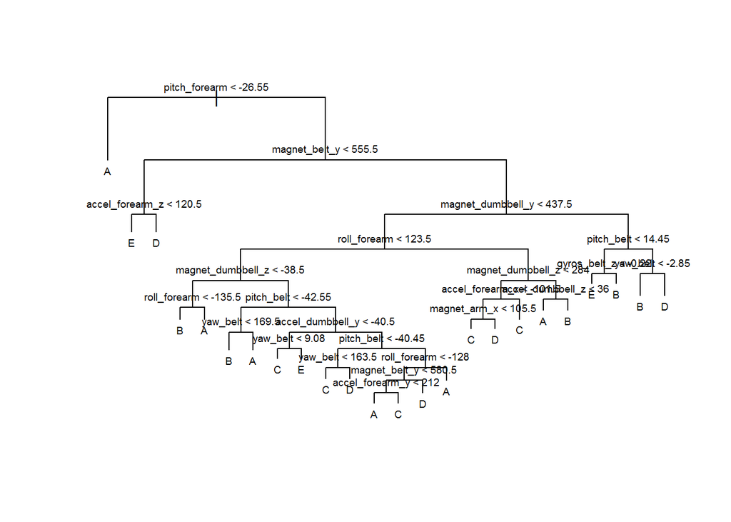

```r
plot(tree.training)
text(tree.training,cex=0.6)
```

The resulting tree is rather messy. It may need some pruning. Another idea is to try recursive partitioning and regression tree (rpart).

### RPART Analysis

```r
modelFit_rpart <- train(classe ~., method = 'rpart',data=myTraining.deCor)
print(modelFit_rpart$finalModel)
```

```
## n= 11776
##
## node), split, n, loss, yval, (yprob)
##       * denotes terminal node
##
##   1) root 11776 8428 A (0.28 0.19 0.17 0.16 0.18)
##     2) pitch_forearm< -33.95 945    8 A (0.99 0.0085 0 0 0) *
##     3) pitch_forearm>=-33.95 10831 8420 A (0.22 0.21 0.19 0.18 0.2)
##       6) magnet_belt_y>=555.5 9933 7524 A (0.24 0.23 0.21 0.18 0.15)
##        12) yaw_belt>=169.5 492   44 A (0.91 0.039 0 0.051 0) *
##        13) yaw_belt< 169.5 9441 7190 B (0.21 0.24 0.22 0.18 0.15)
##          26) magnet_dumbbell_z< -93.5 1128  478 A (0.58 0.29 0.045 0.054 0.038) *
##          27) magnet_dumbbell_z>=-93.5 8313 6311 C (0.16 0.23 0.24 0.2 0.17)
##            54) pitch_belt< -42.95 498   77 B (0.022 0.85 0.094 0.026 0.012) *
##            55) pitch_belt>=-42.95 7815 5860 C (0.17 0.19 0.25 0.21 0.18)
##             110) magnet_dumbbell_x< -446.5 4353 2726 C (0.17 0.12 0.37 0.21 0.14) *
##             111) magnet_dumbbell_x>=-446.5 3462 2466 B (0.17 0.29 0.095 0.22 0.23)
##               222) yaw_belt< 4.49 3124 2129 B (0.19 0.32 0.1 0.24 0.15)
##                 444) accel_dumbbell_y< 48.5 1837 1199 D (0.28 0.19 0.14 0.35 0.042)
##                   888) magnet_belt_z< -374.5 763  309 A (0.6 0.21 0.059 0.05 0.089) *
##                   889) magnet_belt_z>=-374.5 1074  474 D (0.055 0.18 0.2 0.56 0.0084) *
##                 445) accel_dumbbell_y>=48.5 1287  642 B (0.053 0.5 0.04 0.095 0.31) *
##               223) yaw_belt>=4.49 338   18 E (0 0.003 0.05 0 0.95) *
##       7) magnet_belt_y< 555.5 898  176 E (0.0022 0.0011 0.0011 0.19 0.8) *
```

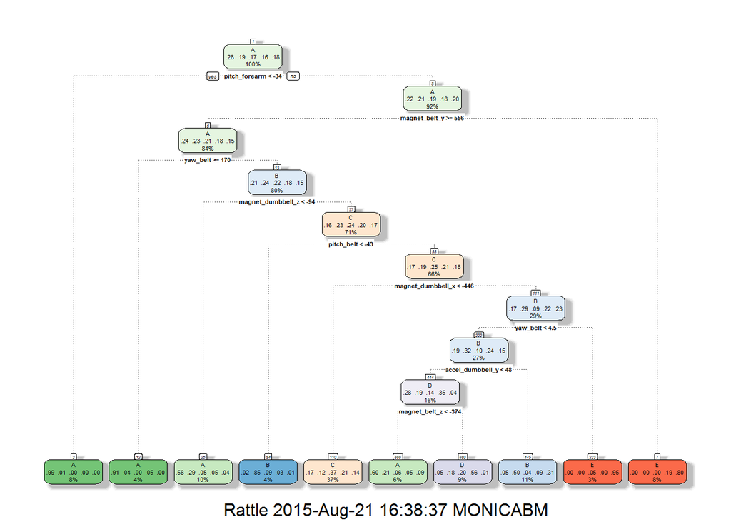

```r
fancyRpartPlot(modelFit_rpart$finalModel)
```

This tree is more managable for interpretation. We can test to see if the regression tree and rpart are equivalant.

```r
tree.pred = predict(tree.training,myTesting.deCor,type="class")
predMatrix = with(myTesting.deCor, table(tree.pred,classe))
#find error rate
sum(diag(predMatrix))/sum(as.vector(predMatrix))
```

```
## [1] 0.7132297
```

```r
tree.pred = predict(modelFit_rpart,myTesting.deCor)
predMatrix = with(myTesting.deCor, table(tree.pred,classe))
#find error rate
sum(diag(predMatrix))/sum(as.vector(predMatrix))
```

```
## [1] 0.5773643
```

It looks like the regression tree approach performs a bit better. With that said, the tree was messy and the actual results are not very accurate. Nevertheless, we can see if pruning the tree will help with interpretation and get us a stellar performance. We will use cross validation to prune the regression tree.

```r
cv.training=cv.tree(tree.training,FUN=prune.misclass)
cv.training
```

```
## $size
##  [1] 24 23 22 20 19 18 17 16 13 10  7  5  1
##
## $dev
##  [1] 3323 3406 3413 3782 4011 4303 4326 5615 5754 5789 5789 6240 8428
##
## $k
##  [1]     -Inf  67.0000  74.0000 105.5000 116.0000 128.0000 136.0000
##  [8] 165.0000 170.0000 172.3333 178.3333 234.0000 554.7500
##
## $method
## [1] "misclass"
##
## attr(,"class")
## [1] "prune"         "tree.sequence"
```

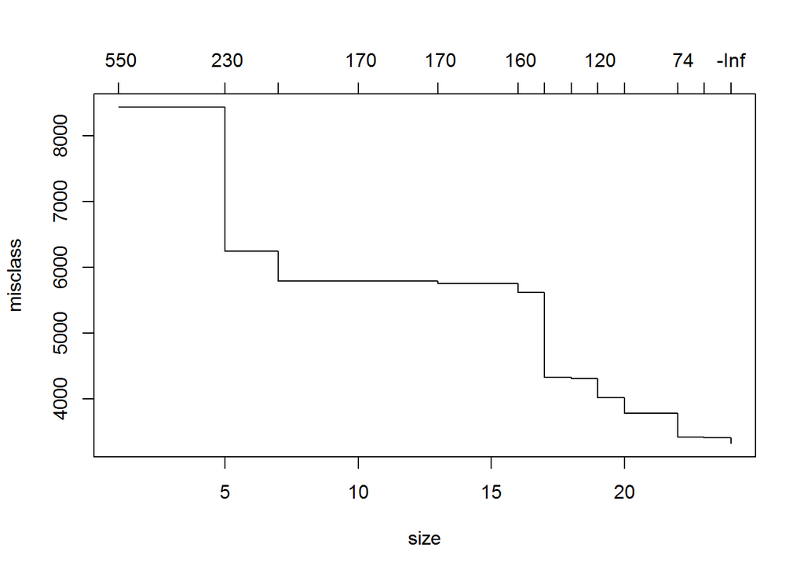

```r
plot(cv.training)
```

Our crossvalidation analysis shows that we could prune the tree at node 20. Lets see if pruning will improve our performance.

```r
prune.training=prune.misclass(tree.training,best=20)
tree.pred = predict(prune.training,myTesting.deCor,type="class")
predMatrix = with(myTesting.deCor, table(tree.pred,classe))
#find error rate
sum(diag(predMatrix))/sum(as.vector(predMatrix))
```

```
## [1] 0.6825134
```

### Random Forest Analysis

```r
RF.training = randomForest(classe~.,data=myTraining.deCor,ntree=100,importance=TRUE)
RF.training
```

```
##
## Call:
##  randomForest(formula = classe ~ ., data = myTraining.deCor, ntree = 100,      importance = TRUE)
##                Type of random forest: classification
##                      Number of trees: 100
## No. of variables tried at each split: 6
##
##         OOB estimate of  error rate: 0.89%
## Confusion matrix:
##      A    B    C    D    E class.error
## A 3343    3    1    0    1 0.001493429
## B   20 2245   12    1    1 0.014918824
## C    0   17 2033    4    0 0.010223953
## D    0    1   28 1896    5 0.017616580
## E    0    0    5    6 2154 0.005080831
```

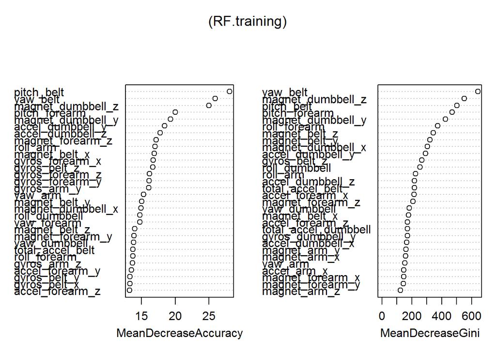

```r
varImpPlot((RF.training))
```

```r
tree.pred = predict(RF.training,myTesting.deCor)
predMatrix = with(myTesting.deCor, table(tree.pred,classe))
#find error rate
sum(diag(predMatrix))/sum(as.vector(predMatrix))
```

```
## [1] 0.993245
```